# Untitled

2026-02-25

```r
library(dplyr)
branch_length <- function(filePath, cell_line){

  branches <- read.table(filePath, header = FALSE, stringsAsFactors = FALSE)


  internal_rows <- grep("internal", branches$V1)

#deleting first internal:
  if(length(internal_rows) > 0){
    branches <- branches[-internal_rows[1], ]
  }


  result <- data.frame(
    cell = branches$V1,
    total_branch_length = branches$V2,
    clone = cell_line,
    stringsAsFactors = FALSE
  )
  result <- result[!grepl("internal", result$cell), ]

  return(result)
}



kuramochi_C8  <- branch_length("Medicc2Results/mcs_Kuramochi_C8_1000kb_branch_lengths.tsv",  "Kuramochi_C8")
kuramochi_E10 <- branch_length("Medicc2Results/mcs_Kuramochi_E10_1000kb_branch_lengths.tsv", "Kuramochi_E10")
kuramochi_parent <- branch_length("Medicc2Results/mcs_Kuramochi_parent_1000kb_branch_lengths.tsv", "Kuramochi_Parent")

#checking the output:
# kuramochi_C8
# kuramochi_E10
# kuramochi_parent

snu_A12 <- branch_length("Medicc2Results/mcs_Snu119_A12_1000kb_branch_lengths.tsv",    "Snu119_A12")
snu_F12 <- branch_length("Medicc2Results/mcs_Snu119_F12_1000kb_branch_lengths.tsv",    "Snu119_F12")
snu_parent <- branch_length("Medicc2Results/mcs_Snu119_parent_1000kb_branch_lengths.tsv","Snu119_parent")

#checking the output:
snu_A12
```

```
##              cell total_branch_length      clone
## 8  SM200303_4_069                  14 Snu119_A12
## 9  SM200303_4_093                  13 Snu119_A12
## 11 SM200303_4_033                  10 Snu119_A12
## 13 SM200303_4_058                  20 Snu119_A12
## 15 SM200303_4_034                  11 Snu119_A12
## 16 SM200303_4_070                  20 Snu119_A12
## 17 SM200303_4_057                  20 Snu119_A12
## 19 SM200303_4_021                  35 Snu119_A12
## 20 SM200303_4_046                  17 Snu119_A12
## 21 SM200303_4_094                  43 Snu119_A12
## 22 SM200303_4_009                  41 Snu119_A12
## 23 SM200303_4_010                  56 Snu119_A12
## 24 SM200303_4_081                  38 Snu119_A12
```

```r
snu_F12
```

```
##              cell total_branch_length      clone
## 7  SM200303_4_012                  60 Snu119_F12
## 8  SM200303_4_059                  18 Snu119_F12
## 10 SM200303_4_024                  25 Snu119_F12
## 11 SM200303_4_047                  26 Snu119_F12
## 13 SM200303_4_095                  19 Snu119_F12
## 15 SM200303_4_035                  20 Snu119_F12
## 16 SM200303_4_071                  20 Snu119_F12
## 17 SM200303_4_060                  17 Snu119_F12
## 18 SM200303_4_083                  34 Snu119_F12
## 19 SM200303_4_036                  22 Snu119_F12
## 20 SM200303_4_072                  38 Snu119_F12
```

```r
snu_parent
```

```
##              cell total_branch_length         clone
## 6  SM200303_4_079                  30 Snu119_parent
## 9  SM200303_4_031                  37 Snu119_parent
## 10 SM200303_4_055                  20 Snu119_parent
## 12 SM200303_4_007                  17 Snu119_parent
## 13 SM200303_4_068                  19 Snu119_parent
## 16 SM200303_4_056                  44 Snu119_parent
## 18 SM200303_4_032                  24 Snu119_parent
## 19 SM200303_4_067                  27 Snu119_parent
## 21 SM200303_4_044                  21 Snu119_parent
## 22 SM200303_4_080                  46 Snu119_parent
## 23 SM200303_4_019                  34 Snu119_parent
## 24 SM200303_4_092                  34 Snu119_parent
## 25 SM200303_4_043                  47 Snu119_parent
## 26 SM200303_4_091                  78 Snu119_parent
```

```r
kuramochi_df <- rbind(kuramochi_C8, kuramochi_E10, kuramochi_parent)
snu119_df <- rbind(snu_A12, snu_F12, snu_parent)


#checking the output:
# kuramochi_df
# snu119_df
```

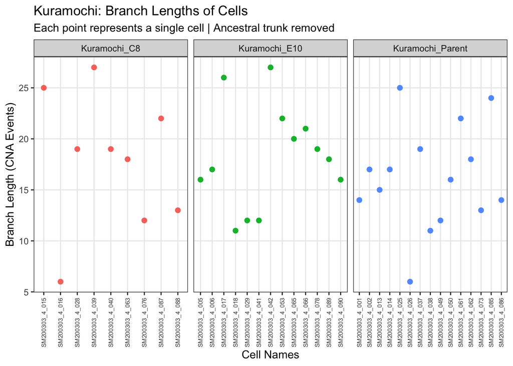

```r
library(ggplot2)

ggplot(kuramochi_df, aes(x = cell, y = total_branch_length, color = clone)) +
  geom_point(size = 2) +
  facet_wrap(~clone, scales = "free_x") +
  theme_bw() +
  labs(title = "Kuramochi: Branch Lengths of Cells",
       subtitle = "Each point represents a single cell | Ancestral trunk removed",
       y = "Branch Length (CNA Events)",
       x = "Cell Names") +
  theme(
    axis.text.x = element_text(angle = 90, vjust = 0.5, size = 6, hjust = 1),
    panel.grid.minor = element_blank(),
    legend.position = "none"
  )
```

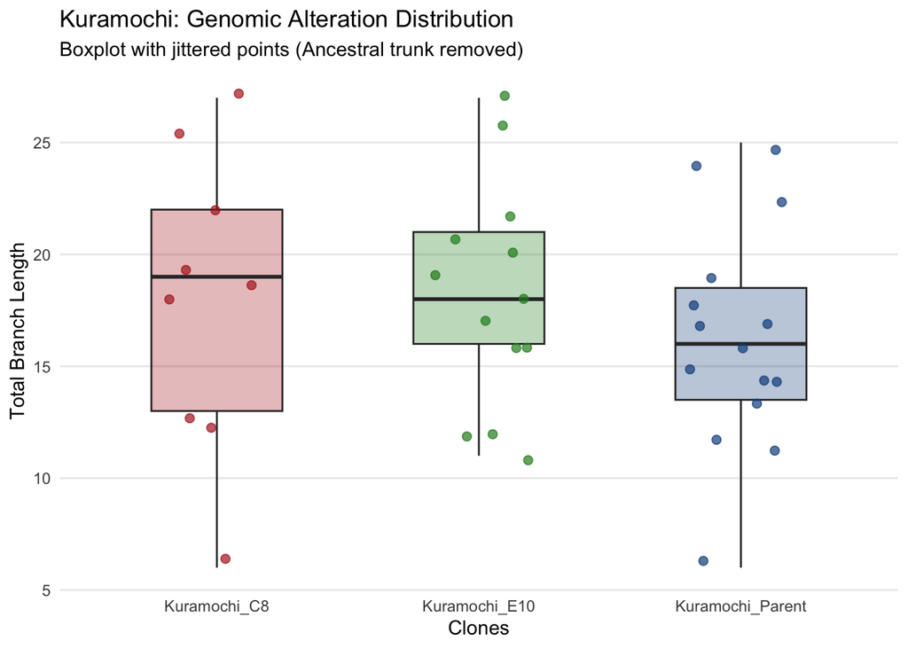

```r
ggplot(kuramochi_df, aes(x = clone, y = total_branch_length, fill = clone)) +
  # ۱. کشیدن باکس پلات در پس‌زمینه
  geom_boxplot(alpha = 0.3, outlier.shape = NA, width = 0.5) +

  # ۲. اضافه کردن نقاط با لرزش (Jitter)
  geom_jitter(aes(color = clone), width = 0.2, size = 2, alpha = 0.7) +

  theme_minimal() +

  # تنظیم دستی رنگ داخل باکس‌ها
  scale_fill_manual(values = c(
    "Kuramochi_C8" = "firebrick",
    "Kuramochi_E10" = "forestgreen",
    "Kuramochi_Parent" = "dodgerblue4"
  )) +

  # تنظیم دستی رنگ نقاط (بهتر است با رنگ باکس‌ها یکی باشد)
  scale_color_manual(values = c(
    "Kuramochi_C8" = "firebrick",
    "Kuramochi_E10" = "forestgreen",
    "Kuramochi_Parent" = "dodgerblue4"
  )) +

  labs(title = "Kuramochi: Genomic Alteration Distribution",
       subtitle = "Boxplot with jittered points (Ancestral trunk removed)",
       y = "Total Branch Length",
       x = "Clones") +

  theme(
    legend.position = "none",
    panel.grid.minor = element_blank(),
    panel.grid.major.x = element_blank()
  )
```

all populations were grown under identical conditions and for 22 cell divisions, the differences in Total Branch Length directly reflect variations in the genomic alteration rate. The higher medians in clones C8 and E10 compared to the parental population indicate that the rate of copy number alterations increased following single-cell isolation. The higher median in C8 signifies the highest rate of genomic evolution in this clone. The greater dispersion of points in C8 compared to E10 indicates more severe chromosomal instability (CIN) and the development of higher intra-clonal heterogeneity within only 22 cell generations.

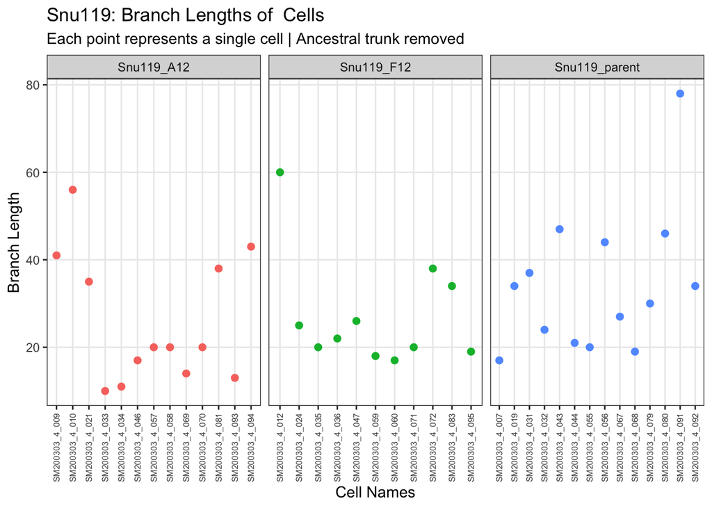

```r
ggplot(snu119_df, aes(x = cell, y = total_branch_length, color = clone)) +
  geom_point(size = 2) +
  facet_wrap(~clone, scales = "free_x") +
  theme_bw() +
  labs(title = "Snu119: Branch Lengths of  Cells",
       subtitle = "Each point represents a single cell | Ancestral trunk removed",
       y = "Branch Length",
       x = "Cell Names") +
  theme(
    axis.text.x = element_text(angle = 90, vjust = 0.5, size = 6, hjust = 1),
    panel.grid.minor = element_blank(),
    legend.position = "none"
  )
```

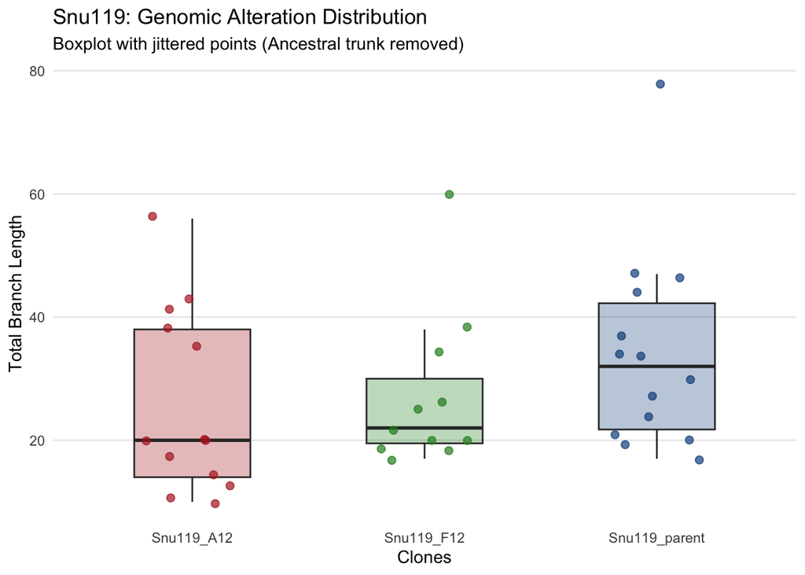

```r
ggplot(snu119_df, aes(x = clone, y = total_branch_length, fill = clone)) +
  # ۱. کشیدن باکس پلات در پس‌زمینه
  geom_boxplot(alpha = 0.3, outlier.shape = NA, width = 0.5) +

  # ۲. اضافه کردن نقاط با لرزش (Jitter)
  geom_jitter(aes(color = clone), width = 0.2, size = 2, alpha = 0.7) +

  theme_minimal() +

  # تنظیم دستی رنگ‌ها (مشابه Kuramochi برای حفظ ثبات بصری)
  scale_fill_manual(values = c(
    "Snu119_A12" = "firebrick",     # رنگ قرمز برای کلون اول
    "Snu119_F12" = "forestgreen",   # رنگ سبز برای کلون دوم (مشابه E10)
    "Snu119_parent" = "dodgerblue4" # رنگ آبی تیره برای Parent
  )) +

  scale_color_manual(values = c(
    "Snu119_A12" = "firebrick",
    "Snu119_F12" = "forestgreen",
    "Snu119_parent" = "dodgerblue4"
  )) +

  labs(title = "Snu119: Genomic Alteration Distribution",
       subtitle = "Boxplot with jittered points (Ancestral trunk removed)",
       y = "Total Branch Length",
       x = "Clones") +

  theme(
    legend.position = "none",
    panel.grid.minor = element_blank(),
    panel.grid.major.x = element_blank()
  )
```

all populations were grown under identical conditions and for 22 cell divisions, the difference in Total Branch Length indicates the difference in the rate of genomic alterations. The higher median in the Parent population compared to the clones shows that single-cell bottlenecking led to the selection of subpopulations with lower genomic alteration rates. Among the clones, F12 has a slightly higher median than A12. At the same time, the greater dispersion in A12 indicates higher CIN and heterogeneity, while F12 shows more uniform genomic alterations.